# Homework6

Lionel Armstrong

March 11, 2018

```r
library(mdsr)
library(tidyverse)
library(dbplyr)
library(ggplot2)
library(mosaicData)
```

# Exercise 1

Load the Whickham dataset (data(Whickham)). You will need to load the mosaicData package first, but I also included the data as an rds file on Canvas if you would rather download it there and load it with readRDS().

Look at the help file on this dataset to learn a bit about it.

```r
?Whickham
```

*1.What variables are in this data set?*

##### ANSWER:

The Whickham dataset has three variables: outcome, smoker, and age.

*2.How many observations are there and what does each represent?*

##### ANSWER:

*3.Create a table (use the R code below as a guide) and a visualization of the relationship between smoking status and outcome, ignoring age. What do you see? Does it make sense?*

##### ANSWER:

Non-smokers die at a higher rate than smokers. This is contary to what is believed to be facts. The ignoring age is likely to account for this.

```r
Whickham %>%count(smoker,outcome)
```

```
## # A tibble: 4 x 3
##   smoker outcome     n
##   <fct>  <fct>   <int>
## 1 No     Alive     502
## 2 No     Dead      230
## 3 Yes    Alive     443
## 4 Yes    Dead      139
```

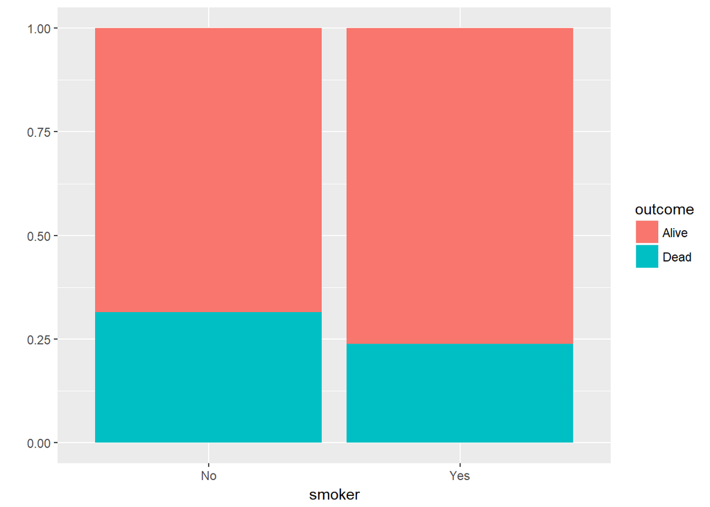

```r
Whickham %>% ggplot(aes(x = smoker, fill = outcome))  +geom_bar(position = 'fill')+labs(y = '')
```

*4.Recode the age variable into an ordered factor with three categories: age <= 44, age > 44 & age <= 64, and age > 64. Now, recreate visualization from above, but facet on your new age factor. What do you see? Does it make sense?*

##### ANSWER:

When broken out by age non-smokers are a higher percentage in each group.

```r
Whickham <- Whickham %>% mutate(age_fct =
                       factor(case_when(
                         age <= 44 ~ '<44',
                         age > 44 & age <= 64 ~'44-64',                              age > 64 ~ '>64'),
                     levels = c('<44', '44-64', '>64')))
```

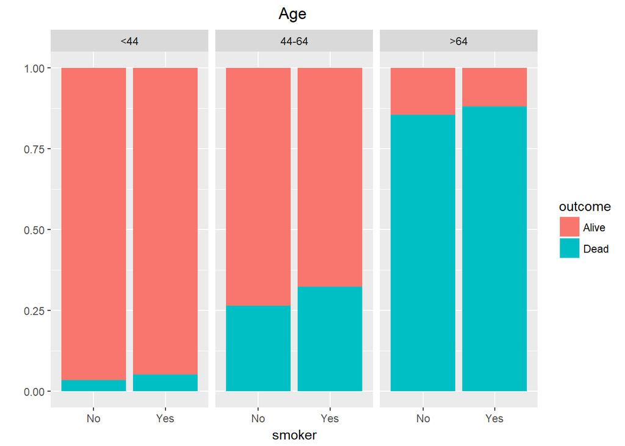

```r
Whickham %>% ggplot(aes(x = smoker, fill = outcome)) +    geom_bar(position = 'fill')+labs(y = '') +
  facet_wrap(~age_fct) +
  ggtitle("                                                 Age")
```

# Exercise 2

The Central Limit Theorem states that the sampling distribution of sample means is approximately Normal, regardless of the distribution of your population. For this exercise our population distribution will be a Gamma(1,2) distribution, and we’ll show that the sampling distribution of the mean is in fact normally distributed.

*1.Generate a random sample of size n = 10000 from a gamma(1,2) distribution and plot a histogram or density curve. Use the code below to help you get your sample.*

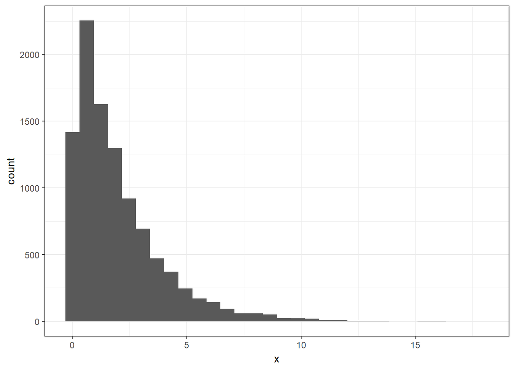

```r
library(tidyverse)
n <- 10000
gamma_samp <- tibble(x = rgamma(n, shape = 1, scale = 2))

gamma_samp %>% ggplot() +
 geom_histogram(aes(x = x)) +
 theme_bw()
```

*look at ?rgamma to read about this function?* *gamma_samp <- tibble(x = rgamma(n, shape = 1, scale = 2))*

```r
gamma_samp %>% .[['x']] %>% mean()
```

```
## [1] 1.991877
```

```r
gamma_samp %>% .[['x']] %>% sd()
```

```
## [1] 1.976078
```

*3.Pretend the distribution of our population of data looks like the plot above. Now take a sample of size n = 30 from a Gamma(1,2) distribution, plot the histogram or density curve, and calculate the mean and standard deviation.*

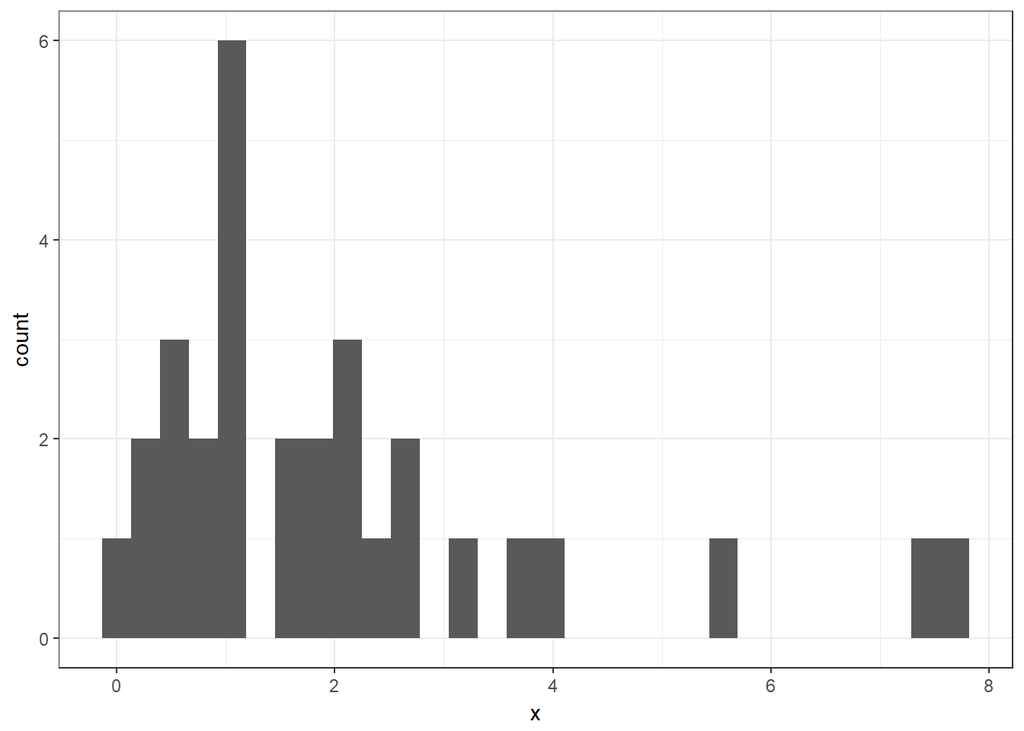

```r
library(tidyverse)
n <- 30
gamma_samp_30 <- tibble(x = rgamma(n, shape = 1, scale = 2))

gamma_samp_30 %>% ggplot() +
 geom_histogram(aes(x = x)) +
 theme_bw()
```

```r
gamma_samp_30 %>% .[['x']] %>% mean()
```

```
## [1] 2.088575
```

```r
gamma_samp_30 %>% .[['x']] %>% sd()
```

```
## [1] 1.954447
```

*4.Take a sample of size n = 30, again from the Gamma(1,2) distribution, calculate the mean, and assign it to a vector named mean_samp. Repeat this 10000 times!!!! The code below might help.*

```r
# create a vector with 10000 NAs
mean_samp <- rep(NA, 10000)

# start a loop
for(i in 1:10000) {
  g_samp <- rgamma(30, shape = 1, scale = 2)
  mean_samp[i] <- mean(g_samp)
}
# Convert vector to a tibble
mean_samp <- tibble(mean_samp)
glimpse(mean_samp)
```

```
## Observations: 10,000
## Variables: 1
## $ mean_samp <dbl> 1.893637, 2.121398, 1.703065, 1.908206, 2.012725, 1....
```

*5.Make a histogram of your collection of means from above (mean_samp).*

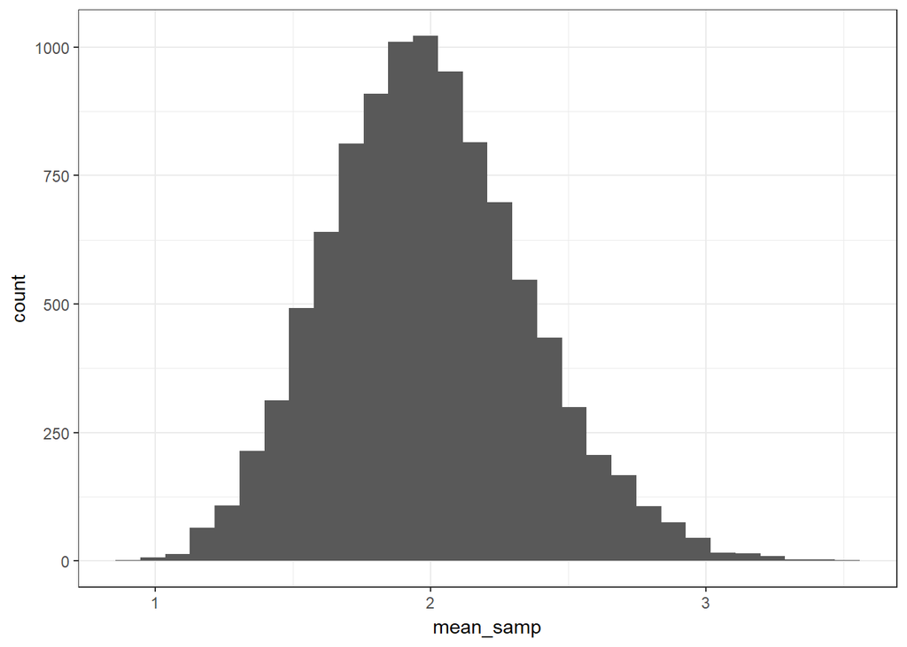

```r
mean_samp %>% ggplot() +
 geom_histogram(aes(x = mean_samp)) +
 theme_bw()
```

*6.Calculate the mean and standard deviation of all of your sample means.*

```r
mean_samp %>% summarize(mean_samp_mean = mean(mean_samp), sd_samp_mean = sd(mean_samp))
```

```
## # A tibble: 1 x 2
##   mean_samp_mean sd_samp_mean
##            <dbl>        <dbl>
## 1           1.99        0.362
```

*7.Did anything surprise you about your answers to #6?*

*Repeat #4-#6, but now with a sample of size n = 300 instead. Do your results match up well with the theorem?*

*Take a sample of size n = 300*

```r
# create a vector with 10000 NAs
mean_samp <- rep(NA, 10000)

# start a loop
for(i in 1:10000) {
  g_samp <- rgamma(300, shape = 1, scale = 2)
  mean_samp[i] <- mean(g_samp)
}
# Convert vector to a tibble
mean_samp <- tibble(mean_samp)
glimpse(mean_samp)
```

```
## Observations: 10,000
## Variables: 1
## $ mean_samp <dbl> 1.966217, 2.078866, 1.898516, 1.960014, 2.118720, 2....
```

*Make a histogram of your collection of means from above (mean_samp).*

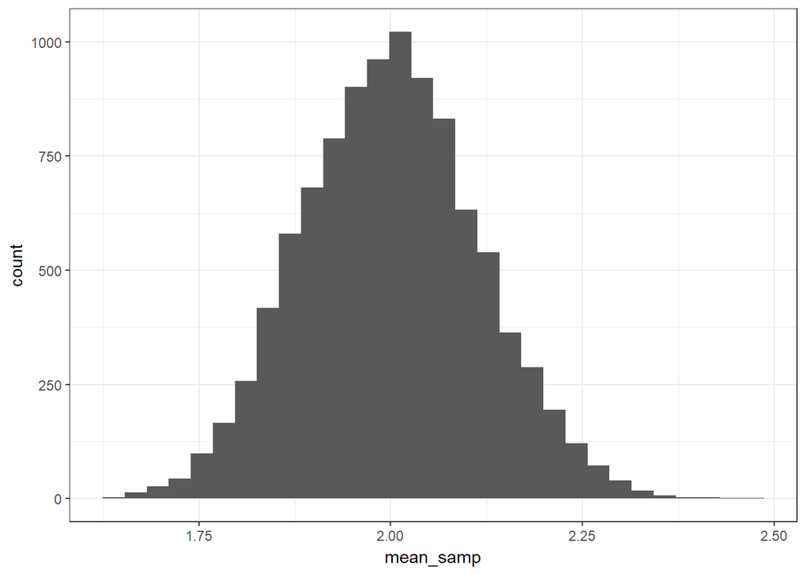

```r
mean_samp %>% ggplot() +
 geom_histogram(aes(x = mean_samp)) +
 theme_bw()
```

*Calculate the mean and standard deviation of all of your sample means.*

```r
mean_samp %>% summarize(mean_samp_mean = mean(mean_samp), sd_samp_mean = sd(mean_samp))
```

```
## # A tibble: 1 x 2
##   mean_samp_mean sd_samp_mean
##            <dbl>        <dbl>
## 1           2.00        0.115
```